# R Notebook

# Libraries

```r
library(glmulti)
```

# Lesson 1 - Overfitting

Data = Pattern + Noise

```r
summary(model_overfit)
```

```
Call:
lm(formula = savings ~ ., data = savings)

Residuals:
   Min     1Q Median     3Q    Max
-32617  -6684   -264   6481  31884

Coefficients: (1 not defined because of singularities)
                             Estimate Std. Error t value Pr(>|t|)
(Intercept)                 2.050e+04  2.591e+03   7.915 5.81e-15 ***
genderMale                 -1.049e+03  1.706e+03  -0.615   0.5386
nameAngus                   1.531e+03  1.755e+03   0.873   0.3830
nameBert                   -1.973e+02  1.726e+03  -0.114   0.9090
nameBonnie                  1.261e+03  1.809e+03   0.697   0.4859
nameCara                   -8.515e+02  1.807e+03  -0.471   0.6376
nameCharles                 2.419e+03  1.786e+03   1.354   0.1759
nameDonald                  1.253e+02  1.823e+03   0.069   0.9452
nameDora                   -5.149e+02  1.995e+03  -0.258   0.7964
nameEd                      1.249e+03  1.693e+03   0.738   0.4606
nameEmmy                   -1.062e+03  1.816e+03  -0.585   0.5587
nameFlorence                9.245e+02  1.833e+03   0.504   0.6142
nameFreddy                  6.287e+02  1.792e+03   0.351   0.7257
nameGilly                  -1.518e+03  1.764e+03  -0.861   0.3896
nameGord                   -1.246e+02  1.756e+03  -0.071   0.9435
nameHarry                   3.218e+02  1.742e+03   0.185   0.8535
nameHelena                  4.456e+02  1.748e+03   0.255   0.7988
nameIndia                   9.007e+02  1.785e+03   0.505   0.6139
nameIvan                    9.941e+02  1.780e+03   0.559   0.5766
nameJimmy                          NA         NA      NA       NA
nameJools                   6.287e+02  1.772e+03   0.355   0.7228
surnameFraser              -1.113e+03  1.673e+03  -0.665   0.5060
surnameGaldie               2.034e+03  1.839e+03   1.106   0.2689
surnameHalcrow             -7.546e+02  1.819e+03  -0.415   0.6783
surnameHenderson           -3.788e+02  1.751e+03  -0.216   0.8288
surnameIrvine               3.610e+03  1.713e+03   2.108   0.0353 *
surnameJamieson             4.129e+02  1.831e+03   0.226   0.8216
surnameJohnson              4.237e+02  1.826e+03   0.232   0.8165
surnameLaurenceso          -3.532e+02  1.839e+03  -0.192   0.8478
surnameLeask                2.301e+03  1.697e+03   1.356   0.1754
surnameManson               1.409e+03  1.670e+03   0.843   0.3992
```

[output cut: 14 more lines]

```
age                         2.473e+02  2.492e+01   9.924  < 2e-16 ***
retiredYes                 -2.120e+04  1.091e+03 -19.425  < 2e-16 ***
locationEdinburgh          -3.907e+02  1.230e+03  -0.318   0.7509
locationGlasgow             9.128e+01  1.200e+03   0.076   0.9394
locationInverness           4.338e+02  1.194e+03   0.363   0.7165
locationOrkney             -1.550e+03  1.223e+03  -1.267   0.2053
locationShetland           -6.597e+02  1.201e+03  -0.549   0.5829
locationStirling            1.018e+02  1.250e+03   0.081   0.9351
locationWestern Isles      -1.211e+03  1.214e+03  -0.998   0.3186
---
Signif. codes:  0 ‘***’ 0.001 ‘**’ 0.01 ‘*’ 0.05 ‘.’ 0.1 ‘ ’ 1

Residual standard error: 9939 on 1147 degrees of freedom
Multiple R-squared:  0.3345,    Adjusted R-squared:  0.3044
F-statistic: 11.09 on 52 and 1147 DF,  p-value: < 2.2e-16
```

```r
summary(model_wellfit)
```

```
Call:
lm(formula = savings ~ salary + age + retired, data = savings)

Residuals:
     Min       1Q   Median       3Q      Max
-31330.5  -6764.2    147.7   6625.2  30518.5

Coefficients:
              Estimate Std. Error t value Pr(>|t|)
(Intercept)  2.125e+04  1.659e+03  12.812  < 2e-16 ***
salary       3.376e-01  6.443e-02   5.239  1.9e-07 ***
age          2.463e+02  2.432e+01  10.127  < 2e-16 ***
retiredYes  -2.102e+04  1.066e+03 -19.710  < 2e-16 ***
---
Signif. codes:  0 ‘***’ 0.001 ‘**’ 0.01 ‘*’ 0.05 ‘.’ 0.1 ‘ ’ 1

Residual standard error: 9918 on 1196 degrees of freedom
Multiple R-squared:  0.309, Adjusted R-squared:  0.3073
F-statistic: 178.3 on 3 and 1196 DF,  p-value: < 2.2e-16
```

```r
summary(model_underfit)
```

```
Call:
lm(formula = savings ~ salary, data = savings)

Residuals:
   Min     1Q Median     3Q    Max
-36246  -7847     62   8127  37386

Coefficients:
             Estimate Std. Error t value Pr(>|t|)
(Intercept) 2.701e+04  1.547e+03  17.459  < 2e-16 ***
salary      3.466e-01  7.679e-02   4.514 6.99e-06 ***
---
Signif. codes:  0 ‘***’ 0.001 ‘**’ 0.01 ‘*’ 0.05 ‘.’ 0.1 ‘ ’ 1

Residual standard error: 11820 on 1198 degrees of freedom
Multiple R-squared:  0.01672,   Adjusted R-squared:  0.0159
F-statistic: 20.38 on 1 and 1198 DF,  p-value: 6.992e-06
```

## Principle of parsimony

Models should be as simple as possible, but no simpler

Goodness of fit - R^2 - adj R^2

- AIC - Akaike information criterion
- BIC - Bayesian info criterion - penalises more strongly, which means you tend towards smaller models

Based on likelihood - different from probability/chance.

Not really goodness of fit measures - really they are relative goodness of fit measures (comparing one model with another model)

R^2 Larger is better A/B IC smaller is better

```r
AIC(model_overfit)
```

```
[1] 25549.42
```

```r
AIC(model_wellfit)
```

```
[1] 25496.62
```

```r
AIC(model_underfit)
```

```
[1] 25915.93
```

```r
BIC(model_overfit)
```

```
[1] 25824.29
```

```r
BIC(model_wellfit)
```

```
[1] 25522.07
```

```r
BIC(model_underfit)
```

```
[1] 25931.2
```

| term | estimate | std.error | statistic | p.value |
| --- | --- | --- | --- | --- |
| (Intercept) | 2.050475e+04 | 2.590725e+03 | 7.91467627 | 5.810126e-15 |
| genderMale | -1.049251e+03 | 1.705698e+03 | -0.61514460 | 5.385813e-01 |
| nameAngus | 1.531378e+03 | 1.754631e+03 | 0.87276344 | 3.829747e-01 |
| nameBert | -1.972695e+02 | 1.725841e+03 | -0.11430338 | 9.090173e-01 |
| nameBonnie | 1.261123e+03 | 1.809011e+03 | 0.69713378 | 4.858603e-01 |
| nameCara | -8.515446e+02 | 1.807460e+03 | -0.47112780 | 6.376391e-01 |
| nameCharles | 2.418738e+03 | 1.786041e+03 | 1.35424545 | 1.759248e-01 |
| nameDonald | 1.252874e+02 | 1.822714e+03 | 0.06873673 | 9.452112e-01 |
| nameDora | -5.149016e+02 | 1.995187e+03 | -0.25807183 | 7.963978e-01 |
| nameEd | 1.249415e+03 | 1.692781e+03 | 0.73808421 | 4.606143e-01 |

[output cut: 44 more lines]

# Lesson 2 - Test / train sets

*split data before we look at it*

- Okay to go through *basic* cleaning steps before splitting
- but don’t explore for patterns or relationships at this point

Create a test set - used to test the model on “unseen” data separate from the training set don’t refer to it ever again until the model is built

The remaining data is our *training* data

We want to use as much of the data as possible for the training phase, but still have enough left to account for variety of cases that might come up.

90 / 10 - 80 / 20 70 / 30

No hard and fast rule, depends on your dataset - how much data do you have?

## Test / train in R

### Fit a model to the **training** set

| savings | pred |
| --- | --- |
| 54245 | 27957.65 |
| 24199 | 40030.45 |
| 29173 | 22814.27 |
| 18381 | 25751.44 |
| 41128 | 26615.05 |
| 43979 | 42118.50 |
| 22533 | 26101.87 |
| 57821 | 42774.75 |
| 50525 | 39492.36 |
| 29197 | 28683.41 |

[output cut: 230 more lines]

```r
mse_test <- mean((predictions_test$pred - test$savings)^2)
mse_test # normally this will be square-rooted --> RMSE
```

```
[1] 106665166
```

```r
sqrt(mse_test)
```

```
[1] 10327.88
```

get data cleaning basic exploration *split data* train model - used to create predictions compare model on test set

## Task - 10 mi9nutes

Calculate the mean squared error between predicted saving and actual savings in the training dataset

Which is higher, then error on the test or the error on the training data? Is this what you would expect

```r
predictions_train <- train %>%
  add_predictions(model) %>%
  select(savings, pred)

mse_train <- mean((predictions_train$pred - train$savings)^2)
mse_train # normally this will be square-rooted --> RMSE
```

```
[1] 96034515
```

```r
sqrt(mse_train)
```

```
[1] 9799.72
```

The error is lower on the training set, I would expect this b/c the model was trained on the data from this set and not on the data from the test set, so I would expect the model to perform better on the data is was trained on.

# Lesson 3 - K-fold validation

Bias - variance trade-off - a model with high bias (and low variance) won’t match the dataset closely, while a model with low bias (and high variance) will match the dataset very closely

Hyperparameters - a model setting (how is the model going to work) in K2 validation, you can tweak them to fit the data better

```r
model
```

```
Linear Regression

1200 samples
   3 predictor

No pre-processing
Resampling: Cross-Validated (10 fold)
Summary of sample sizes: 1080, 1080, 1080, 1080, 1080, 1080, ...
Resampling results:

  RMSE      Rsquared   MAE
  9896.834  0.3152612  7902.707

Tuning parameter 'intercept' was held constant at a value of TRUE
```

| pred | obs | rowIndex | intercept | Resample |
| --- | --- | --- | --- | --- |
| 25928.45 | 14662 | 16 | TRUE | Fold01 |
| 37469.01 | 43525 | 18 | TRUE | Fold01 |
| 37941.99 | 48657 | 30 | TRUE | Fold01 |
| 40121.62 | 37135 | 36 | TRUE | Fold01 |
| 37427.74 | 32043 | 59 | TRUE | Fold01 |
| 25290.98 | 31160 | 66 | TRUE | Fold01 |
| 42856.77 | 33818 | 83 | TRUE | Fold01 |
| 25763.96 | 32660 | 85 | TRUE | Fold01 |
| 24756.24 | 30085 | 91 | TRUE | Fold01 |
| 41653.83 | 23704 | 98 | TRUE | Fold01 |

[output cut: 990 more lines]

| RMSE | Rsquared | MAE | Resample |
| --- | --- | --- | --- |
| 10669.741 | 0.3406485 | 8603.247 | Fold01 |
| 10333.100 | 0.2271195 | 8139.450 | Fold02 |
| 8340.169 | 0.4552094 | 6742.725 | Fold03 |
| 9364.178 | 0.3818896 | 7471.393 | Fold04 |
| 9636.160 | 0.2811805 | 7794.606 | Fold05 |
| 11008.679 | 0.1987878 | 8876.362 | Fold06 |
| 11062.921 | 0.2320150 | 8750.427 | Fold07 |
| 9105.973 | 0.4651649 | 7026.382 | Fold08 |
| 9360.507 | 0.2833562 | 7498.990 | Fold09 |
| 10086.908 | 0.2872408 | 8123.492 | Fold10 |

```r
mean(model$resample$RMSE)
```

```
[1] 9896.834
```

### Task -

Find the average error and the average r-squared value across each fold, after doing a 10 fold cross validation using the model which has all the variables in it. What does this tell you? Are these values as expected

```r
mean(model2$resample$RMSE)
```

```
[1] 10194.96
```

## Test, training and validation sets

20 / 80 - test, train 20 / 60 / 20 - test, train, validate

Hyperparameters - “model settings”

data some model — lots of different *types* of model fit several models with varying *hyperparameters* use the *validation* set to choose our hyperparameters retrain model on entire training set (60 + 20) test on the test set

## Avoiding leaks

*split before we look at it*

- okay to go through *basic* cleaning steps
- but don’t explore for patterns or relationship at this point
- might be okay looking for some correlation
- how would we handle NAs

if you impute *before* you split, realise the imputed values in the test set have been influenced by the train set - important that the test dataset has *no connection* to the train dataset and imputing before splitting could cause data leakage from the test dataset into the training set (and training set into the test set).

clean explore(minimally *split* training set imputations train model (validate) test set imputations

We can prevent data leakage by ensuring our pre-processing is done in the training dataset separately from our testing/validation set, as well as ensuring the variables we select are useful predictors that would be available to us at the point that we want to apply our model.

# Lesson 4 - Automated model development

## Learning objectives

- Understand _forward_selection, *backwards* selection and *best subset* selection
- Learn how to use the ‘leaps’ package
- Understand the *limitations* of automated model selection

## Forward selection

- Starts with a “Null” model -intercept only
- At each step, we check all predictors
- Find the one that raises adj R^2 the most
- Add that predictor to the model
1. prestige ~ education
2. prestige ~ eduction + income
3. prestige ~ education + income + type
4. prestige ~ education + income + type + income:type

## Backwards selection

- Start with a “FULL” model
- Remove preds sequentially, see with lowers the adj R^2 the least
  - remove from the model

## Best subset

- Find all possible combinations of predictors and interactions
- Keep the one with the best metric

*options increase exponentially* Very computationally intensive

**predictive vs explanatory** modelling

## Leaps package

-Limitations -it will happily include only some levels of a categorical variable - which is generally considered bad practice -it does not handle interactions very well -we can only test model fit using penalised measures of fit, not using test/train splits or K-fold cross validation

```r
summary(regsubsets_forward)
```

```
Subset selection object
Call: regsubsets.formula(charges ~ ., data = insurance, nvmax = 8,
    method = "forward")
8 Variables  (and intercept)
                Forced in Forced out
age                 FALSE      FALSE
sexmale             FALSE      FALSE
bmi                 FALSE      FALSE
children            FALSE      FALSE
smokeryes           FALSE      FALSE
regionnorthwest     FALSE      FALSE
regionsoutheast     FALSE      FALSE
regionsouthwest     FALSE      FALSE
1 subsets of each size up to 8
Selection Algorithm: forward
         age sexmale bmi children smokeryes regionnorthwest regionsoutheast regionsouthwest
1  ( 1 ) " " " "     " " " "      "*"       " "             " "             " "
2  ( 1 ) "*" " "     " " " "      "*"       " "             " "             " "
3  ( 1 ) "*" " "     "*" " "      "*"       " "             " "             " "
4  ( 1 ) "*" " "     "*" "*"      "*"       " "             " "             " "
5  ( 1 ) "*" " "     "*" "*"      "*"       " "             "*"             " "
6  ( 1 ) "*" " "     "*" "*"      "*"       " "             "*"             "*"
7  ( 1 ) "*" " "     "*" "*"      "*"       "*"             "*"             "*"
8  ( 1 ) "*" "*"     "*" "*"      "*"       "*"             "*"             "*"
```

```r
sum_regsubsets_forward$which
```

```
  (Intercept)   age sexmale   bmi children smokeryes regionnorthwest regionsoutheast regionsouthwest
1        TRUE FALSE   FALSE FALSE    FALSE      TRUE           FALSE           FALSE           FALSE
2        TRUE  TRUE   FALSE FALSE    FALSE      TRUE           FALSE           FALSE           FALSE
3        TRUE  TRUE   FALSE  TRUE    FALSE      TRUE           FALSE           FALSE           FALSE
4        TRUE  TRUE   FALSE  TRUE     TRUE      TRUE           FALSE           FALSE           FALSE
5        TRUE  TRUE   FALSE  TRUE     TRUE      TRUE           FALSE            TRUE           FALSE
6        TRUE  TRUE   FALSE  TRUE     TRUE      TRUE           FALSE            TRUE            TRUE
7        TRUE  TRUE   FALSE  TRUE     TRUE      TRUE            TRUE            TRUE            TRUE
8        TRUE  TRUE    TRUE  TRUE     TRUE      TRUE            TRUE            TRUE            TRUE
```

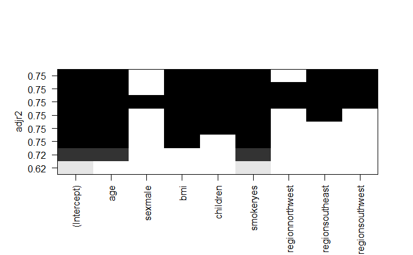

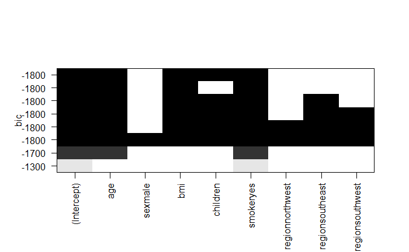

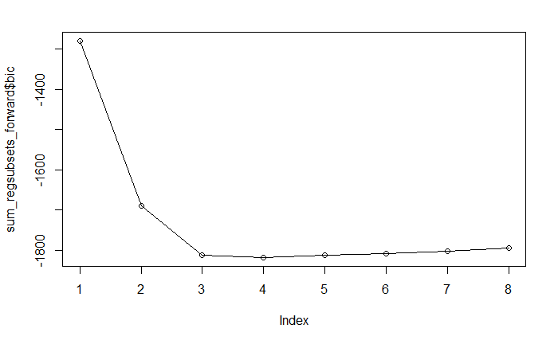

## Task 10 min

Re-run the analyses above using the backward selection and exhaustive search variable selection methods

Compare the tables (or plots, whichever you find easier) showing which predictors are included for forward selection, backward selection, and exhaustive search.

Do you find any differences? Use adjusted R-squared as your measure of fit.

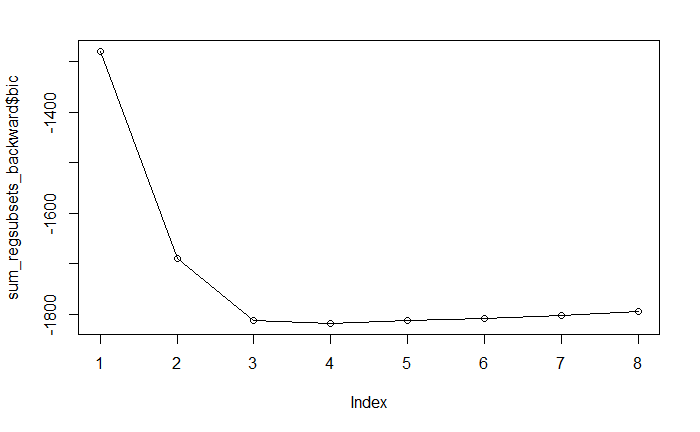

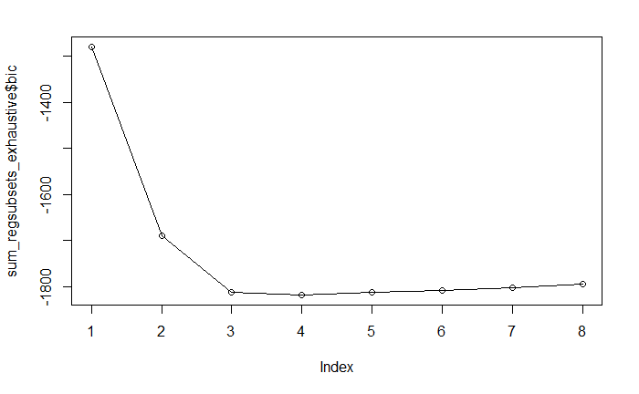

```r
summary(regsubsets_exhaustive)$which[6, ]
```

```
    (Intercept)             age         sexmale             bmi        children       smokeryes regionnorthwest regionsoutheast
           TRUE            TRUE           FALSE            TRUE            TRUE            TRUE           FALSE            TRUE
regionsouthwest
           TRUE
```

```r
summary(mod_with_region)
```

```
Call:
lm(formula = charges ~ age + bmi + children + smoker + region,
    data = insurance)

Residuals:
     Min       1Q   Median       3Q      Max
-11367.2  -2835.4   -979.7   1361.9  29935.5

Coefficients:
                 Estimate Std. Error t value Pr(>|t|)
(Intercept)     -11990.27     978.76 -12.250  < 2e-16 ***
age                256.97      11.89  21.610  < 2e-16 ***
bmi                338.66      28.56  11.858  < 2e-16 ***
children           474.57     137.74   3.445 0.000588 ***
smokeryes        23836.30     411.86  57.875  < 2e-16 ***
regionnorthwest   -352.18     476.12  -0.740 0.459618
regionsoutheast  -1034.36     478.54  -2.162 0.030834 *
regionsouthwest   -959.37     477.78  -2.008 0.044846 *
---
Signif. codes:  0 ‘***’ 0.001 ‘**’ 0.01 ‘*’ 0.05 ‘.’ 0.1 ‘ ’ 1

Residual standard error: 6060 on 1330 degrees of freedom
Multiple R-squared:  0.7509,    Adjusted R-squared:  0.7496
F-statistic: 572.7 on 7 and 1330 DF,  p-value: < 2.2e-16
```

```r
anova(mod_without_region, mod_with_region)
```

```
Analysis of Variance Table

Model 1: charges ~ age + bmi + children + smoker
Model 2: charges ~ age + bmi + children + smoker + region
  Res.Df        RSS Df Sum of Sq      F  Pr(>F)
1   1333 4.9078e+10
2   1330 4.8845e+10  3 233200844 2.1166 0.09631 .
---
Signif. codes:  0 ‘***’ 0.001 ‘**’ 0.01 ‘*’ 0.05 ‘.’ 0.1 ‘ ’ 1
```

| age | sex | bmi | children | smoker | region | charges | location |
| --- | --- | --- | --- | --- | --- | --- | --- |
| 19 | female | 27.900 | 0 | yes | southwest | 16884.924 | south |
| 18 | male | 33.770 | 1 | no | southeast | 1725.552 | south |
| 28 | male | 33.000 | 3 | no | southeast | 4449.462 | south |
| 33 | male | 22.705 | 0 | no | northwest | 21984.471 | north |
| 32 | male | 28.880 | 0 | no | northwest | 3866.855 | north |
| 31 | female | 25.740 | 0 | no | southeast | 3756.622 | south |
| 46 | female | 33.440 | 1 | no | southeast | 8240.590 | south |
| 37 | female | 27.740 | 3 | no | northwest | 7281.506 | north |
| 37 | male | 29.830 | 2 | no | northeast | 6406.411 | north |
| 60 | female | 25.840 | 0 | no | northwest | 28923.137 | north |

[output cut: 990 more lines]

```r
mod_region_comb <- lm(charges ~ age + bmi + children + smoker + location,
                         data = insurance)
summary(mod_region_comb)
```

```
Call:
lm(formula = charges ~ age + bmi + children + smoker + location,
    data = insurance)

Residuals:
     Min       1Q   Median       3Q      Max
-11342.9  -2843.3   -978.6   1359.8  29893.1

Coefficients:
               Estimate Std. Error t value Pr(>|t|)
(Intercept)   -12144.70     940.46 -12.914  < 2e-16 ***
age              257.06      11.88  21.639  < 2e-16 ***
bmi              337.86      28.13  12.012  < 2e-16 ***
children         472.20     137.55   3.433 0.000615 ***
smokeryes      23839.60     410.65  58.053  < 2e-16 ***
locationsouth   -820.40     341.16  -2.405 0.016318 *
---
Signif. codes:  0 ‘***’ 0.001 ‘**’ 0.01 ‘*’ 0.05 ‘.’ 0.1 ‘ ’ 1

Residual standard error: 6057 on 1332 degrees of freedom
Multiple R-squared:  0.7508,    Adjusted R-squared:  0.7498
F-statistic: 802.5 on 5 and 1332 DF,  p-value: < 2.2e-16
```

```r
anova(mod_without_region, mod_region_comb)
```

```
Analysis of Variance Table

Model 1: charges ~ age + bmi + children + smoker
Model 2: charges ~ age + bmi + children + smoker + location
  Res.Df        RSS Df Sum of Sq      F  Pr(>F)
1   1333 4.9078e+10
2   1332 4.8866e+10  1 212155241 5.7829 0.01632 *
---
Signif. codes:  0 ‘***’ 0.001 ‘**’ 0.01 ‘*’ 0.05 ‘.’ 0.1 ‘ ’ 1
```

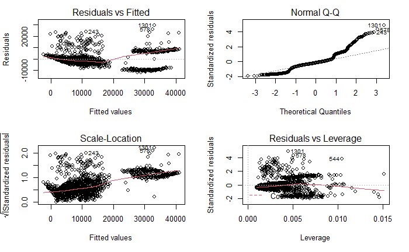

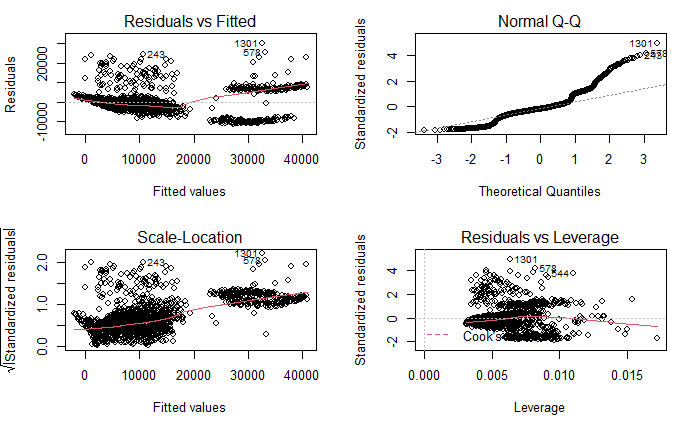

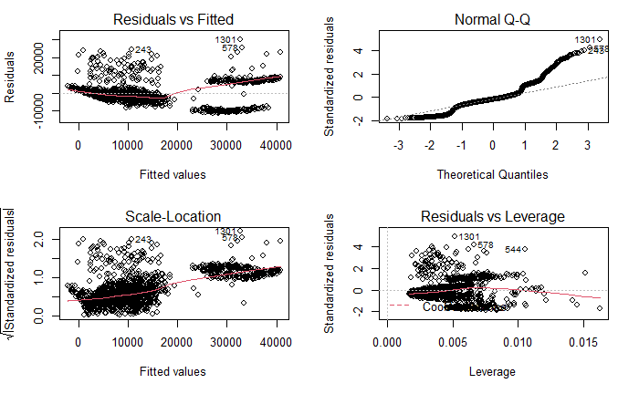

```r
par(mfrow = c(2, 2))
plot(mod_without_region)
plot(mod_with_region)

plot(mod_region_comb)
```

```r
summary(regsubsets_exhaustive)$which[4, ]
```

```
    (Intercept)             age         sexmale             bmi        children       smokeryes regionnorthwest regionsoutheast
           TRUE            TRUE           FALSE            TRUE            TRUE            TRUE           FALSE           FALSE
regionsouthwest
          FALSE
```

```r
summary(mod_4_subset)
```

```
Call:
lm(formula = charges ~ age + bmi + children + smoker, data = insurance)

Residuals:
     Min       1Q   Median       3Q      Max
-11897.9  -2920.8   -986.6   1392.2  29509.6

Coefficients:
             Estimate Std. Error t value Pr(>|t|)
(Intercept) -12102.77     941.98 -12.848  < 2e-16 ***
age            257.85      11.90  21.675  < 2e-16 ***
bmi            321.85      27.38  11.756  < 2e-16 ***
children       473.50     137.79   3.436 0.000608 ***
smokeryes    23811.40     411.22  57.904  < 2e-16 ***
---
Signif. codes:  0 ‘***’ 0.001 ‘**’ 0.01 ‘*’ 0.05 ‘.’ 0.1 ‘ ’ 1

Residual standard error: 6068 on 1333 degrees of freedom
Multiple R-squared:  0.7497,    Adjusted R-squared:  0.7489
F-statistic: 998.1 on 4 and 1333 DF,  p-value: < 2.2e-16
```